# STAT 184 Homework Exercises

DataComputing Chapters 7

zhiyaun zhang

###question 7.1 ##1 reduction ##2 reduction ##3 reduction ##4 transformation ##5 neither ##6 reduction ##7 could determine by using reduction function ##8 reduction

```r
rm(list = ls())

library(tidyverse)
```

```r
library(mosaic)
library(mosaicData)
library(dcData)

data("Minneapolis2013", package = "dcData")
Minneapolis2013 %>%
  summarise(count = n())
```

| count |
| --- |
| 80101 |

```r
Minneapolis2013 %>%
    group_by(Second) %>%
    summarise(count = n()) %>%
    arrange(desc(count)) %>%
    head(5)
```

| Second | count |
| --- | --- |
| BETSY HODGES | 14399 |
| DON SAMUELS | 14170 |
| MARK ANDREW | 12757 |
| undervote | 10598 |
| JACKIE CHERRYHOMES | 6470 |

```r
Minneapolis2013 %>%
    group_by(First) %>%
    summarise(count = n()) %>%
    filter(First == "undervote")
```

| First | count |
| --- | --- |
| undervote | 834 |

```r
Minneapolis2013 %>%
    group_by(Second) %>%
    summarise(count = n()) %>%
    filter(Second == "undervote")
```

| Second | count |
| --- | --- |
| undervote | 10598 |

```r
Minneapolis2013 %>%
    group_by(Third) %>%
    summarise(count = n()) %>%
    filter(Third == "undervote")
```

| Third | count |
| --- | --- |
| undervote | 19210 |

```r
Minneapolis2013 %>%
    group_by(First, Second) %>%
    summarise(count = n()) %>%
    arrange(desc(count)) %>%
    head(3)
```

| First | Second | count |
| --- | --- | --- |
| BETSY HODGES | MARK ANDREW | 8787 |
| BETSY HODGES | DON SAMUELS | 8743 |
| MARK ANDREW | BETSY HODGES | 6970 |

```r
Minneapolis2013 %>%
    group_by(Precinct) %>%
    summarise(count = n()) %>%
    arrange(desc(count)) %>%
    head(1)
```

| Precinct | count |
| --- | --- |
| P-06 | 9711 |

### Question7.5

##1 this uis the data that acounts for first and second group combination ##2 this is the case that counts for totol cases for each voters ##3 this is the cases tha counts for total cases for first and second voters’ combination ##4 this is the total cases for the voters group by the first and second vote

```r
VoterData_A <-
  Minneapolis2013 %>%
  group_by(First, Second)

head(VoterData_A)
```

| Precinct | First | Second | Third | Ward |
| --- | --- | --- | --- | --- |
| P-10 | BETSY HODGES | undervote | undervote | W-7 |
| P-06 | BOB FINE | MARK ANDREW | undervote | W-10 |
| P-09 | KURTIS W. HANNA | BOB FINE | MIKE GOULD | W-10 |
| P-05 | BETSY HODGES | DON SAMUELS | undervote | W-13 |
| P-01 | DON SAMUELS | undervote | undervote | W-5 |
| P-04 | undervote | undervote | undervote | W-6 |

```r
VoterData_B <-
  Minneapolis2013 %>%
  summarise(total = n())

VoterData_B
```

| total |
| --- |
| 80101 |

```r
VoterData_C <-
  Minneapolis2013 %>%
  group_by(First, Second) %>%
  summarise(total = n())
VoterData_C
```

| First | Second | total |
| --- | --- | --- |
| ABDUL M RAHAMAN "THE ROCK" | ABDUL M RAHAMAN "THE ROCK" | 69 |
| ABDUL M RAHAMAN "THE ROCK" | ALICIA K. BENNETT | 3 |
| ABDUL M RAHAMAN "THE ROCK" | BETSY HODGES | 29 |
| ABDUL M RAHAMAN "THE ROCK" | BILL KAHN | 18 |
| ABDUL M RAHAMAN "THE ROCK" | BOB "AGAIN" CARNEY JR | 3 |
| ABDUL M RAHAMAN "THE ROCK" | BOB FINE | 3 |
| ABDUL M RAHAMAN "THE ROCK" | CAM WINTON | 2 |
| ABDUL M RAHAMAN "THE ROCK" | CAPTAIN JACK SPARROW | 8 |
| ABDUL M RAHAMAN "THE ROCK" | CYD GORMAN | 1 |
| ABDUL M RAHAMAN "THE ROCK" | DAN COHEN | 2 |

[output cut: 1139 more lines]

###question6

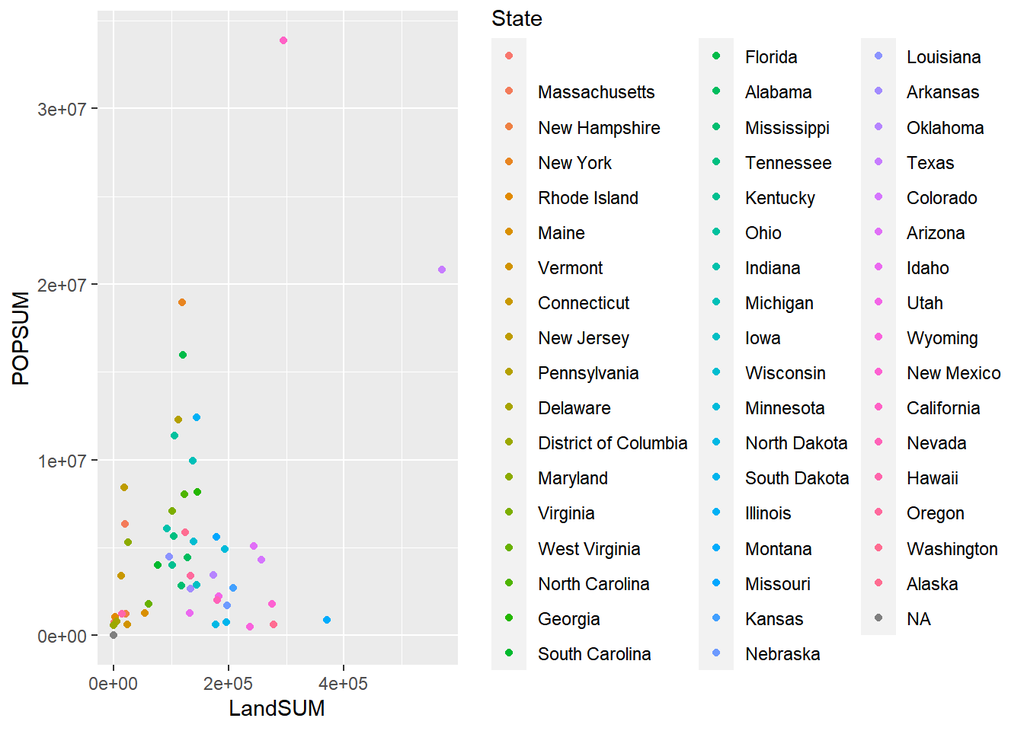

```r
data("ZipGeography")

LandPop <- ZipGeography %>%
  group_by(State) %>%
  summarise(POPSUM = sum(Population, na.rm = TRUE),
            LandSUM = sum(LandArea, na.rm = TRUE),
            POPperLandSUM = sum(Population, na.rm = TRUE)/sum(LandArea, na.rm = TRUE))

# make scatter plot showing relationship (used interactive command like `mplot(LandPop)`)
ggplot(data = LandPop,
       aes(x = LandSUM,
           y = POPSUM)) +
  geom_point() +
  aes(colour = State)
```

```r
LandPop %>%
  mUSMap(key = "State", fill = "POPSUM")
```

```
## Mapping API still under development and may change in future releases.
```

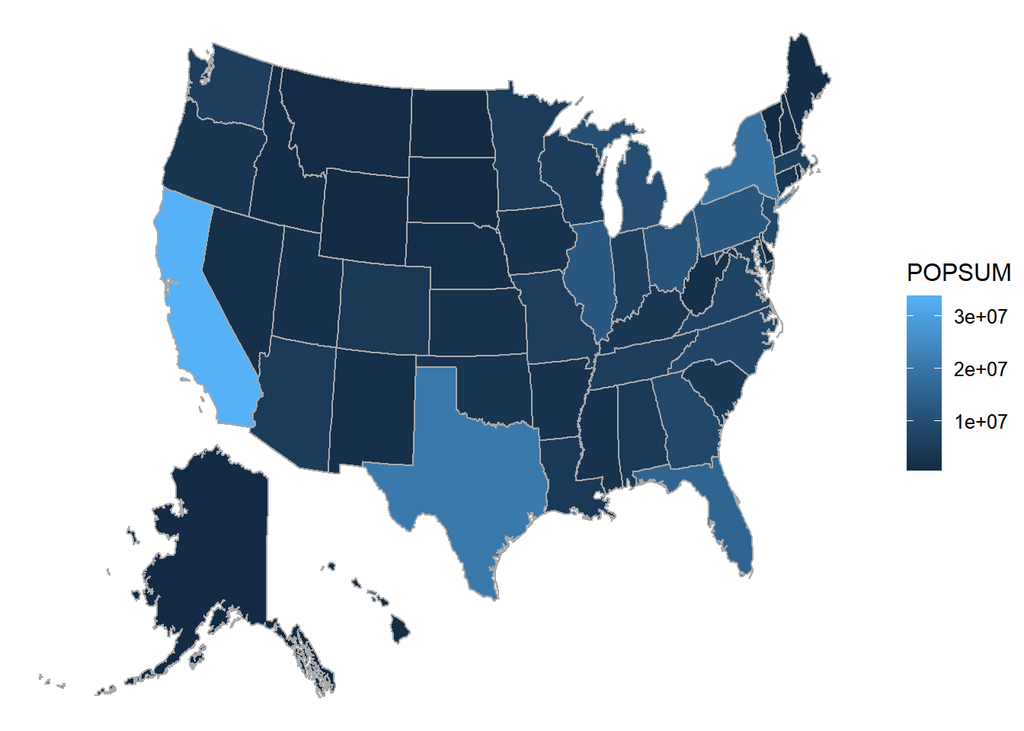

```r
LandPop %>%
  mUSMap(key = "State", fill = "POPperLandSUM")
```

```
## Mapping API still under development and may change in future releases.
```

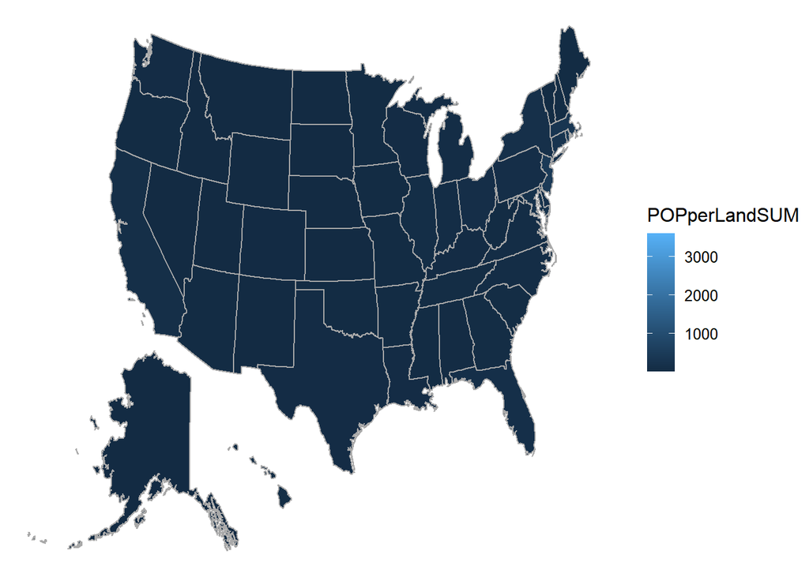

###question7.7 ##a gives the data about mean and number of the data which filtered by sex ##b gives the data about mean and number of the data which filtered by diagnosis ##c gives the data about mean and number of the data which filtered by sex and diagnosis combination ##d gives the data about mean and number of the data which filtered by diagnosis and age combination ##e gives the data about mean and number of the data which filtered by age

###question 7.8

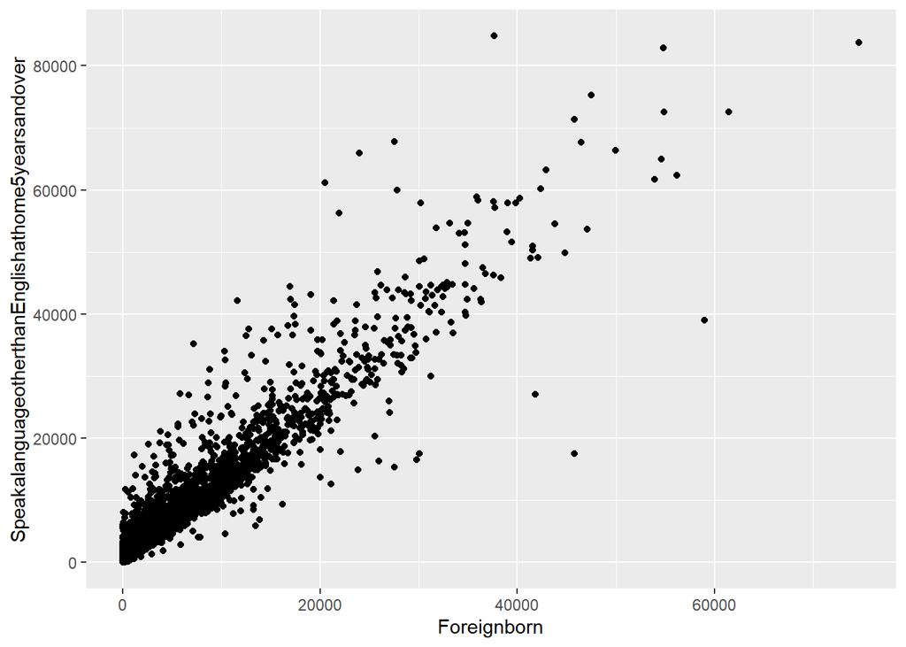

```r
data("ZipDemography", package = "dcData")

ggplot(ZipDemography,
       aes(x = Foreignborn, y = SpeakalanguageotherthanEnglishathome5yearsandover)) +
  geom_point()
```